# Лабораторная работа №5

Презентация

Дзахмишев Камбулат Заурович

Российский университет дружбы народов, Москва, Россия

8 марта 2025

# Информация

## Докладчик

- Дзахмишев Камбулат Заурович
- студент 3 курса
- Российский университет дружбы народов
- 1132221887@pfur.ru
- https://github.com/kzdzakhmishev/study_2024-2025_simmod

## Цель работы

Реализуйте модель SIR в OpenModelica.

## Задание

В дополнение к предположениям, которые были сделаны для модели SIR (5.1) , пред- положим, что учитываются демографические процессы, в частности, что смертность в популяции полностью уравновешивает рождаемость, а все рожденные индивидуу- мы появляются на свет абсолютно здоровыми. Тогда получим следующую систему уравнений:    ˙s = −βs(t)i(t) + μ(N − s(t)); ˙i = βs(t)i(t) − νi(t) − μi(t); ˙r = νi(t) − μr(t),

## Задание

где μ — константа, которая равна коэффициенту смертности и рождаемости. Требуется: – реализовать модель SIR с учётом процесса рождения / гибели особей в xcos (в том числе и с использованием блока Modelica), а также в OpenModelica; – построить графики эпидемического порога при различных значениях параметров модели (в частности изменяя параметр μ); – сделать анализ полученных графиков в зависимости от выбранных значений параметров модели.

## Выполнение лабораторной работы

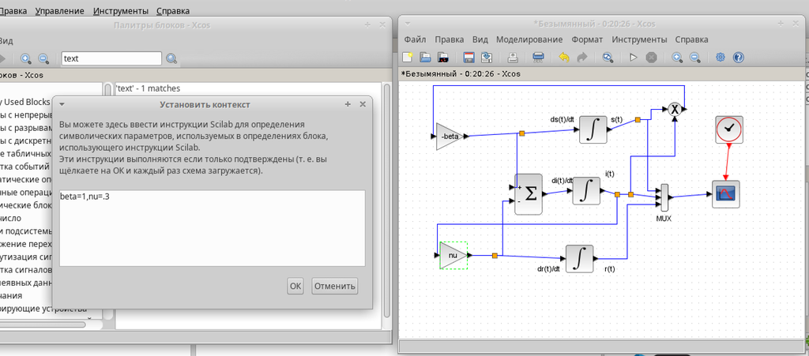

Установка контекста и создание блочной модели

## Выполнение лабораторной работы

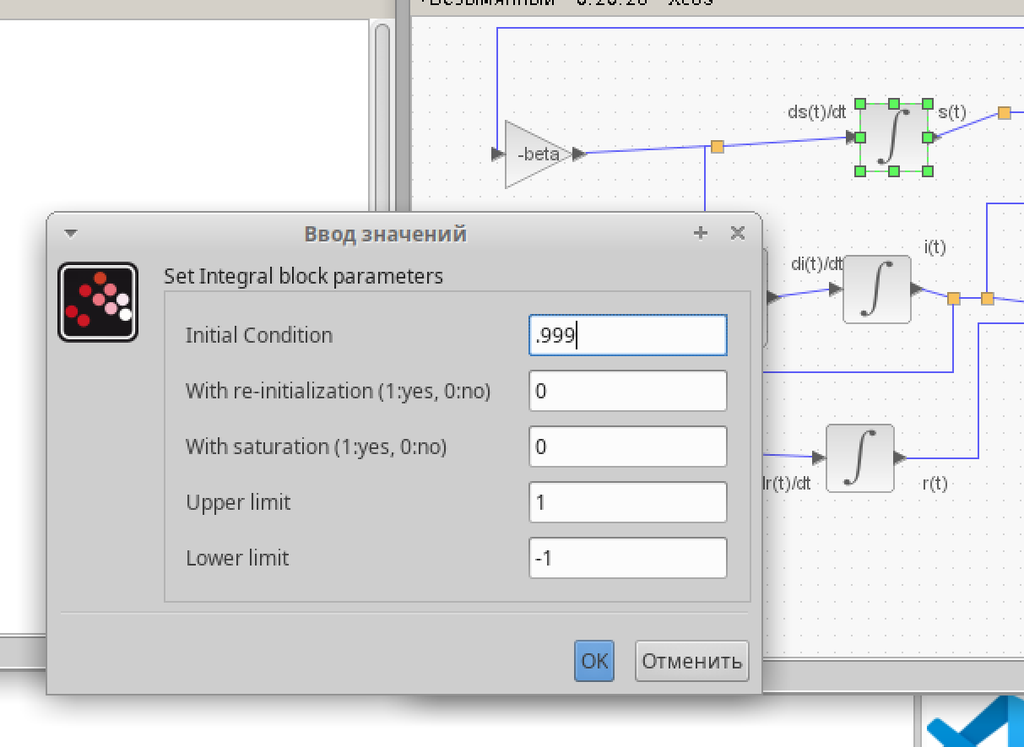

Ввод значений начального состояния верхнего интеграла

## Выполнение лабораторной работы

[figure not shown]

Ввод значений начального состояния нижнего интеграла

## Выполнение лабораторной работы

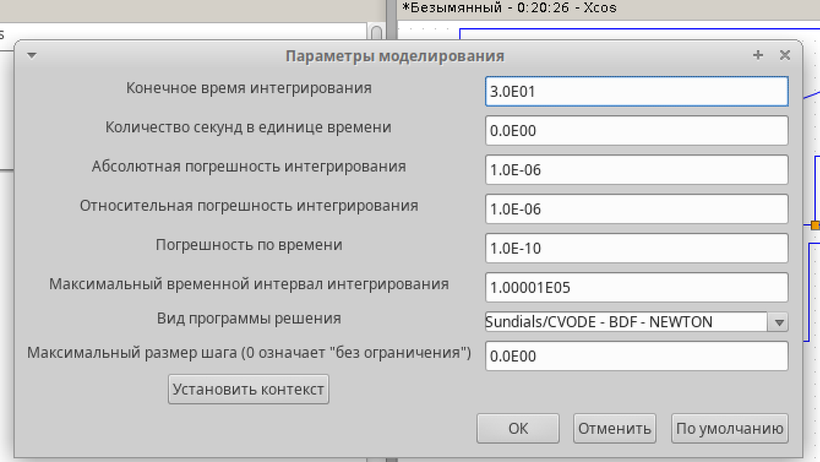

Установка конечного времени интегрирования

В нашем случае оно равно 30.

## Выполнение лабораторной работы

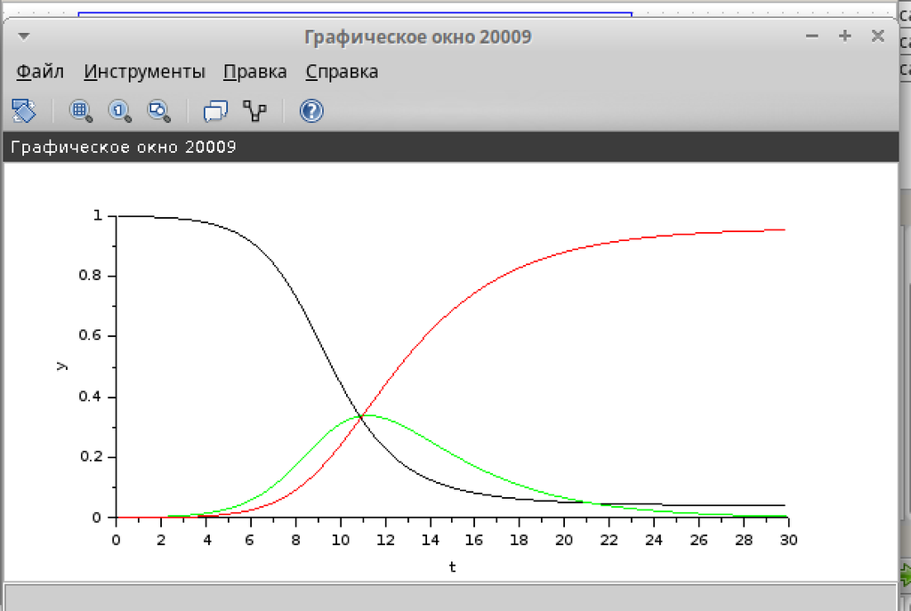

График модели эпидемии в xcos

## Выполнение лабораторной работы

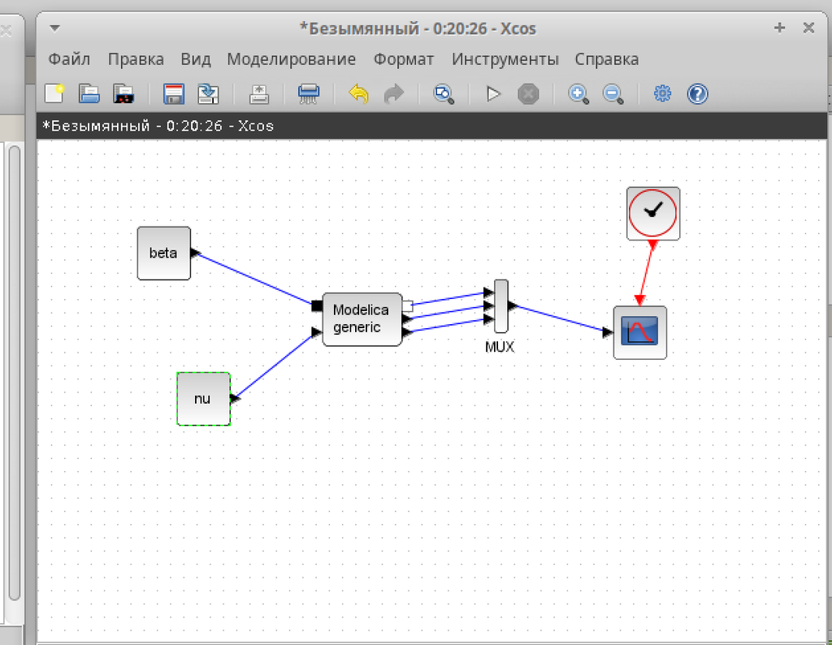

Реализация модели с помощью блока Modelica в xcos

В процессе установки параметров блока Моделика Я забыл сделать скриншот с вводом значений для него, к сожалению. График выходит тем же, что и раньше.

## Выполнение лабораторной работы

[figure not shown]

Код для нашей SIR в OpenModelica

Также установил здесь время конечное равное 30 единицам. На выводе графика имеем тот же график, что и в предыдущих пунктах, только в OprnModelica.

## Выполнение лабораторной работы

[figure not shown]

Модель для самостоятельного задания в OpenModelica

## Выполнение лабораторной работы

[figure not shown]

График модели эпидемии

## Выполнение лабораторной работы

[figure not shown]

График модели эпидемии и её модель в xcos

Уже здесь изменять начал устанавливать другой контекст, изменяя параметр mu.

## Выполнение лабораторной работы

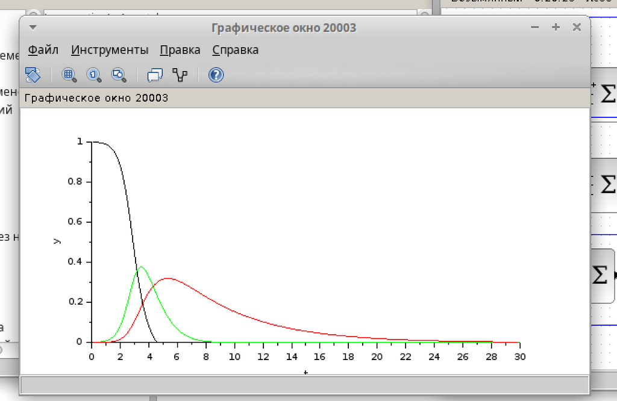

График модели эпидемии с изменёнными параметрами

## Выполнение лабораторной работы

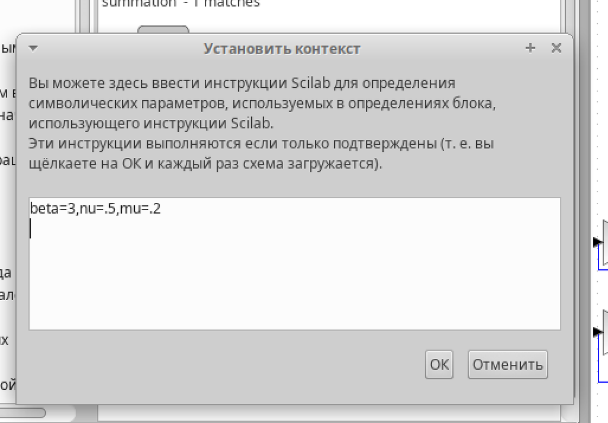

Изменение контекста к предыдущему графику

Здесь можно заметить, что число здоровых людей резко идет на спад, что влечёт по логиче за собой и резкое увеличение числа зараженных.

## Выводы

В ходе данной лабораторной работы составил графики и модели эпидемии, а также научился изменять параметры модели с целью ознакомления с ходом развития эпидемии.

## Список литературы